# Univariate Poisson Model

Petr Keil

January 2016

This brief lesson introduces the concept of **discrete distribution** (**probability mass function**) on the example of Poisson distribution. We will also do more likelihood stuff.

# 1 Poisson distribution

Poisson distribution is a simple model for discrete and **positive count data**.

$p\left( x \right) = \frac{{e^{ - \lambda } \lambda ^x }}{{x!}}$

Where $\lambda$ is the only parameter, which is also the mean of the distribution.

# 2 Simulating poisson data

Let’s explore the Poisson model a bit and simulate some data using `rpois()`:

```r
rpois(n=100, lambda=1)
```

```
##   [1] 0 1 0 2 0 0 0 0 0 1 0 0 3 0 1 1 1 2 2 0 2 0 4 2 1 0 0 0 0 0 0 1 1 1 2
##  [36] 0 0 2 0 1 1 3 0 0 1 2 0 1 1 0 1 3 0 2 0 1 0 1 0 1 0 1 1 0 1 1 1 2 1 2
##  [71] 0 2 0 0 2 2 1 2 1 0 0 2 1 2 1 1 0 2 1 1 1 1 0 0 2 0 1 0 0 2
```

Now try different values of $\lambda$.

We can plot the “empirical frequency histogram” for simulated data with 3 different values of parameter $\lambda$:

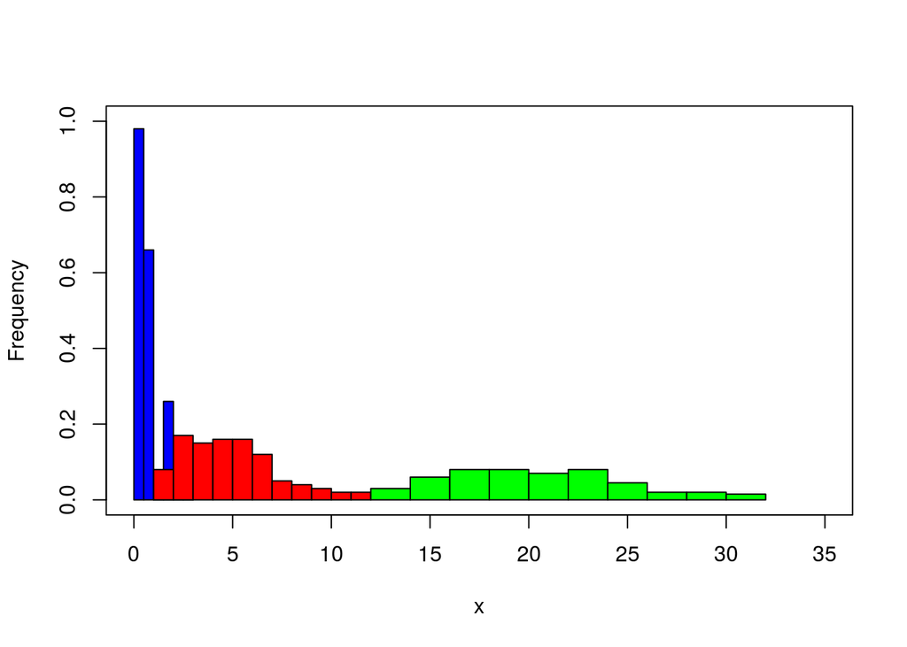

```r
  plot(c(0,35), c(0,1), type="n",
       xlab="x", ylab="Frequency")

  hist(rpois(n=100, lambda=1), add=T, freq=FALSE, col="blue")
  hist(rpois(n=100, lambda=5), add=T, freq=FALSE, col="red")
  hist(rpois(n=100, lambda=20), add=T, freq=FALSE, col="green")
```

Now we can plot the respective **probability mass functions**:

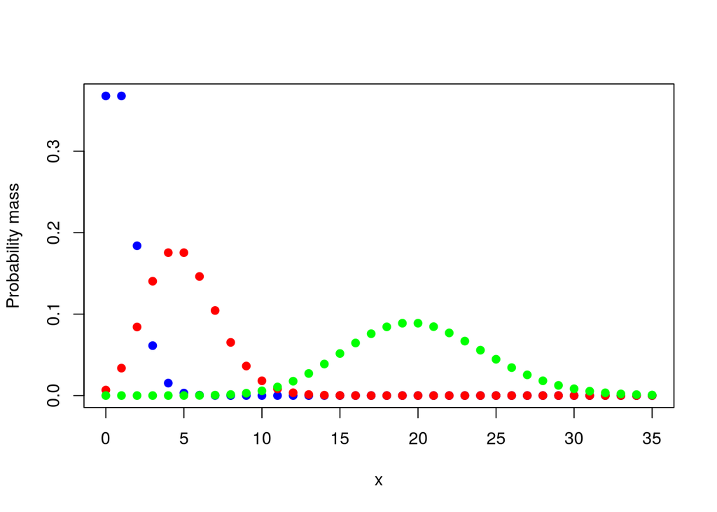

```r
  plot(0:35, dpois(0:35, lambda=1),
       col="blue", pch=19,
       ylab="Probability mass",
       xlab="x")
  points(0:35, dpois(0:35, lambda=5), col="red", pch=19)
  points(0:35, dpois(0:35, lambda=20), col="green", pch=19)
```

# 3 Poisson likelihood

I will generate the artificial data again:

```r
x <- rpois(n=100, lambda=8)
x
```

```
##   [1]  7  8  7  5 18  7  7  4  6  7  9  8  7 11 15  7  7  4  6  5 12 12  9
##  [24]  3  6  9  5 12  6  8 11  7  8 10  9 11  9 11  4  7  7  7  3  7  5 14
##  [47] 11 11 11  6  2 11  9 11 10  9  7  2 11  6  8  7  7  6 10  5 10  7  5
##  [70]  9 14  8 14  9  7  7  9  3 10  9 12 11  8  5  3  5  9  8  4 11  7  8
##  [93]  9  5  9  4  8  5  6  9
```

Poisson distribution is didactically convenient as it only has the one parameter $\lambda$. We can write the *deviance* (negative log-likelihood) function for a given dataset $x$:

```r
  deviance.function <- function(x, lambda)
  {
    LL <- dpois(x, lambda, log=TRUE) # the log likelihood
    deviance <- -sum(LL)
    return(deviance)
  }
```

We can try different values of $\lambda$:

```r
  deviance.function(x, lambda=10)
```

```
## [1] 270.6436
```

And we can evaluate the `deviance.function` for values of $\lambda$ between 0 and 35:

```r
  lambdas <- 0:35
  deviances <- numeric(36) # empty numeric vector

  for(i in 1:36)
  {
    deviances[i] <- deviance.function(x, lambdas[i])
  }
```

Let’s check what we have:

```r
  deviances
```

```
##  [1]       Inf 1198.8962  748.5373  526.5980  398.1785  321.0025  276.2392
##  [8]  253.8435  247.8196  254.2999  270.6436  294.9673  325.8803  362.3264
## [15]  403.4847  448.7043  497.4607  549.3248  603.9410  661.0116  720.2848
## [22]  781.5454  844.6085  909.3138  975.5215 1043.1088 1111.9675 1182.0017
## [29] 1253.1258 1325.2633 1398.3455 1472.3104 1547.1019 1622.6692 1698.9659
## [36] 1775.9498
```

Our **maximum likelihood exstimate (MLE) of $\lambda$** is:

```r
MLE <- lambdas[which.min(deviances)]
MLE
```

```
## [1] 8
```

And this is the plot of the deviance function, together with the MLE (vertical line):

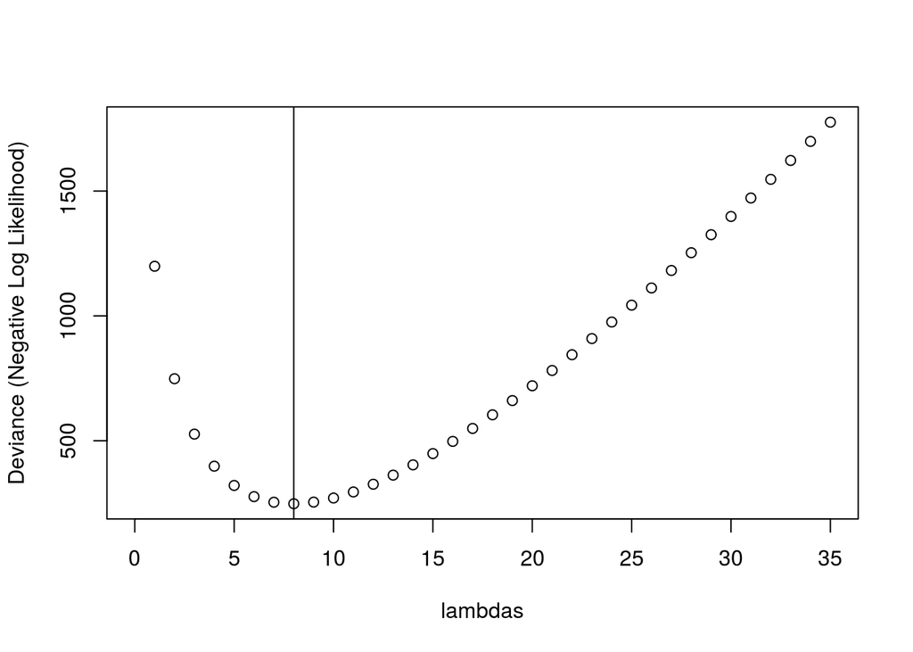

```r
plot(lambdas, deviances, ylab="Deviance (Negative Log Likelihood)")
abline(v=MLE)
```